# voinov_lab1

```python
"""

@author Luke Voinov, 14 Sep. 2025

Much of the code was adapted from Eric Larson's github,  particularly the notebook '03. DataVisualization.ipynb'

https://github.com/eclarson/MachineLearningNotebooks/tree/master

I will denote the notebook '03. DataVisualization.ipynb' with (1).


As you will see, the dataset is about teen phone addiction and lifestyle, linked below:

"Teen Phone Addiction and Lifestyle Survey". https://www.kaggle.com/datasets/khushikyad001/teen-phone-addiction-and-lifestyle-survey?resource=download

"""
# This section of code is borrowed from (1) to get the libraries

import numpy as np
import pandas as pd
import matplotlib.pyplot as plt
import seaborn as sns

print('Seaborn:', sns. __version__)
print('Pandas:', pd.__version__)
print('Numpy:',np.__version__)
# Python: 3.12.3
```

```
Seaborn: 0.13.2
Pandas: 2.2.2
Numpy: 1.26.4
```

### Is this dataset valid for the assignment?

*1. The data includes categorical features (it can also include other forms of data, but must have categorical data)*

Yes, the dataset includes categorical data (e.g. gender, grades (can categoraize them as 'A', 'B', etc.))

*2. The data must be 1,000 rows or larger*

The dataset claims to contain 2933 unique values

*3. The data is not strictly image or text data (but could have these data)*

While some of the dataset is text, there's many numeric data points assocaited with each teen. ChatGPT also agreed that it's not sitrctly these.

*4. The dataset should have some prediction task associated with it (i.e., labels to learn, classification)*

From the dataset description, we read that this dataset "aims to help analyze correlations between phone addiction and various aspects of adolescent life", meaning it's a correlation task. More obviously, the description says that it's "designed for ... machine learning applications such as behavioral prediction, clustering, and health risk classification".

### Business Understanding

*In your own words, give an overview of the dataset. Describe the purpose of the data set you selected (i.e., why and how was this data collected in the first place?). What is the prediction task for your data and why are other third parties interested in the result? Once you begin modeling, how well would your prediction algorithm need to perform to be considered useful to these third parties? Be specific and use your own words to describe the aspects of the data. Be sure to provide a link or citation to your chosen dataset.*

This is a synthetically generated dataset (I noticed this too late into the assignment) that contains information about teenager phone usage (e.g. how addicted they are, what they use their phone for, how much time they spend on certain apps) and their lifestyle (e.g. depression, anxiety, academic performance). The kaggle dataset says that while the data is synthetic, it "simulates real-world data on teenage phone usage habits". This dataset has 2961 downloads and other people have used it to draw their own conclusions about correlations. A syntehtic dataset isn't the best choice, but I treated it as though it is real and it's at least comforting to know that it simulates real data.

The prediction tasks for the data are clustering and classification but I mainly use it to cluster.

Third-parties are interested in these prediction tasks because it provides much needed knowledge about a widely used medium scientists suspect of causing cognitive decline. Thus, the relations shown in this data analysis can leand further support to the idea that increased phone usage is correlated with cognitive decline. This in turn would encourage people to practice safer phone usage, much like public knowledge about the damage of cigarettes deters people from smoking.

My prediction algorithm would have to show an above average (aka significant) correlation between phone addiction and cogntive decline (such as decreased academic success). To be superbly successful, it would not only have to show a significant correaltion but also eliminate any other variables to demonstrate causality.

### Data Understanding (3 points total)

*Load the dataset and appropriately define data types.*

```python
# This section of code is borrowed from (1) to briefly show what the dataset is about

df = pd.read_csv('https://raw.githubusercontent.com/lukeVoinov/Machine-Learning-in-Python/refs/heads/main/Lab%201%20-%20Data%20Visualization/teen_phone_addiction_dataset.csv') # read in the csv file
df.head()
```

|  | ID | Name | Age | Gender | Location | School_Grade | Daily_Usage_Hours | Sleep_Hours | Academic_Performance | Social_Interactions | ... | Screen_Time_Before_Bed | Phone_Checks_Per_Day | Apps_Used_Daily | Time_on_Social_Media | Time_on_Gaming | Time_on_Education | Phone_Usage_Purpose | Family_Communication | Weekend_Usage_Hours | Addiction_Level |
| --- | --- | --- | --- | --- | --- | --- | --- | --- | --- | --- | --- | --- | --- | --- | --- | --- | --- | --- | --- | --- | --- |
| 0 | 1 | Shannon Francis | 13 | Female | Hansonfort | 9th | 4.0 | 6.1 | 78 | 5 | ... | 1.4 | 86 | 19 | 3.6 | 1.7 | 1.2 | Browsing | 4 | 8.7 | 10.0 |
| 1 | 2 | Scott Rodriguez | 17 | Female | Theodorefort | 7th | 5.5 | 6.5 | 70 | 5 | ... | 0.9 | 96 | 9 | 1.1 | 4.0 | 1.8 | Browsing | 2 | 5.3 | 10.0 |
| 2 | 3 | Adrian Knox | 13 | Other | Lindseystad | 11th | 5.8 | 5.5 | 93 | 8 | ... | 0.5 | 137 | 8 | 0.3 | 1.5 | 0.4 | Education | 6 | 5.7 | 9.2 |
| 3 | 4 | Brittany Hamilton | 18 | Female | West Anthony | 12th | 3.1 | 3.9 | 78 | 8 | ... | 1.4 | 128 | 7 | 3.1 | 1.6 | 0.8 | Social Media | 8 | 3.0 | 9.8 |
| 4 | 5 | Steven Smith | 14 | Other | Port Lindsaystad | 9th | 2.5 | 6.7 | 56 | 4 | ... | 1.0 | 96 | 20 | 2.6 | 0.9 | 1.1 | Gaming | 10 | 3.7 | 8.6 |

5 rows × 25 columns

```python
df.describe()
```

|  | ID | Age | Daily_Usage_Hours | Sleep_Hours | Academic_Performance | Social_Interactions | Exercise_Hours | Anxiety_Level | Depression_Level | Self_Esteem | Parental_Control | Screen_Time_Before_Bed | Phone_Checks_Per_Day | Apps_Used_Daily | Time_on_Social_Media | Time_on_Gaming | Time_on_Education | Family_Communication | Weekend_Usage_Hours | Addiction_Level |
| --- | --- | --- | --- | --- | --- | --- | --- | --- | --- | --- | --- | --- | --- | --- | --- | --- | --- | --- | --- | --- |
| count | 3000.000000 | 3000.000000 | 3000.000000 | 3000.000000 | 3000.000000 | 3000.000000 | 3000.000000 | 3000.000000 | 3000.000000 | 3000.000000 | 3000.000000 | 3000.000000 | 3000.000000 | 3000.000000 | 3000.000000 | 3000.000000 | 3000.000000 | 3000.000000 | 3000.000000 | 3000.000000 |
| mean | 1500.500000 | 15.969667 | 5.020667 | 6.489767 | 74.947333 | 5.097667 | 1.040667 | 5.590000 | 5.460333 | 5.546333 | 0.507333 | 1.006733 | 83.093000 | 12.609333 | 2.499233 | 1.525267 | 1.016333 | 5.459667 | 6.015100 | 8.881900 |
| std | 866.169729 | 1.989489 | 1.956501 | 1.490713 | 14.684156 | 3.139333 | 0.734620 | 2.890678 | 2.871557 | 2.860754 | 0.500030 | 0.492878 | 37.747044 | 4.611486 | 0.988201 | 0.932701 | 0.648341 | 2.864572 | 2.014776 | 1.609598 |
| min | 1.000000 | 13.000000 | 0.000000 | 3.000000 | 50.000000 | 0.000000 | 0.000000 | 1.000000 | 1.000000 | 1.000000 | 0.000000 | 0.000000 | 20.000000 | 5.000000 | 0.000000 | 0.000000 | 0.000000 | 1.000000 | 0.000000 | 1.000000 |
| 25% | 750.750000 | 14.000000 | 3.700000 | 5.500000 | 62.000000 | 2.000000 | 0.500000 | 3.000000 | 3.000000 | 3.000000 | 0.000000 | 0.700000 | 51.000000 | 9.000000 | 1.800000 | 0.800000 | 0.500000 | 3.000000 | 4.700000 | 8.000000 |
| 50% | 1500.500000 | 16.000000 | 5.000000 | 6.500000 | 75.000000 | 5.000000 | 1.000000 | 6.000000 | 5.000000 | 6.000000 | 1.000000 | 1.000000 | 82.000000 | 13.000000 | 2.500000 | 1.500000 | 1.000000 | 5.000000 | 6.000000 | 10.000000 |
| 75% | 2250.250000 | 18.000000 | 6.400000 | 7.500000 | 88.000000 | 8.000000 | 1.500000 | 8.000000 | 8.000000 | 8.000000 | 1.000000 | 1.400000 | 115.250000 | 17.000000 | 3.200000 | 2.200000 | 1.500000 | 8.000000 | 7.400000 | 10.000000 |
| max | 3000.000000 | 19.000000 | 11.500000 | 10.000000 | 100.000000 | 10.000000 | 4.000000 | 10.000000 | 10.000000 | 10.000000 | 1.000000 | 2.600000 | 150.000000 | 20.000000 | 5.000000 | 4.000000 | 3.000000 | 10.000000 | 14.000000 | 10.000000 |

*What data type should be used to represent each data attribute? Discuss the attributes collected in the dataset. For datasets with a large number of attributes, only discuss a subset of relevant attributes.*

My dataset contains a large number of attributes so I will try to list the most relevant ones or if they're a unique datatype

- Age: Categorial, int

  Age should be represented this way because there's no significance in the order of ages and age is discrete. Could be stored as a hash.
- Gender: Categorical, int (?)

  Gender is also discrete and has no significance order-wise. Could be stored via one-hot encoding.
- Daily_Usage_Hours, Time_on_Social_Media: Numeric, double

  These are already represented as a double.
- Academic_Performance: Categorical, char

  These could further be categorized as a letter grade, which I will later implement.
- Social_Interactions, Phone_Checks_Per_Day: Categorical, str

  These will also be grouped into something along the lines of "Severe, Average, Mild".
- Addiction_Level: Numeric, double

  The survey somehow measured addiction to single decimal precision.

*Verify data quality: Explain any missing values or duplicate data. Visualize entries that are missing/complete for different attributes. Are those mistakes? Why do these quality issues exist in the data? How do you deal with these problems? Give justifications for your methods (elimination or imputation).*

At a quick glance and search throught the dataset, it looks like there's no missing data (e.g., no NaNs or duplicates)

This can be shown a few ways:

1. Checking if each row has the same number of non-empy columns. If a column is empty, there's missing data.
2. Checking if a name repeats. Duplicated data means a same person was input at least twice. This implies that their name was input at least twice (unless it weirdly put in another name but the same data for the rest of the features, which I assume is unlikely to happen). Since their name is the most distincitve thing about them, this is the best search to make.
3. Checking if there are any "NaN"s. This one is simple enough for a ctrl+f search, but since there's a few nancy's in the dataset, I'll run some code

```python
"""
1 & 3. This function searches for the values None, NaN, NaT, pandas.NA and excludes them from the count.
"""

print(df.count())

"""
From df.describe() we saw that each column has 3k data points. Thus, since none had anything excluded, I conclude there are no 'NaN's or 'None's in this dataset.
This is also supported by what the kaggle dataset reports.
"""
```

```
ID                        3000
Name                      3000
Age                       3000
Gender                    3000
Location                  3000
School_Grade              3000
Daily_Usage_Hours         3000
Sleep_Hours               3000
Academic_Performance      3000
Social_Interactions       3000
Exercise_Hours            3000
Anxiety_Level             3000
Depression_Level          3000
Self_Esteem               3000
Parental_Control          3000
Screen_Time_Before_Bed    3000
Phone_Checks_Per_Day      3000
Apps_Used_Daily           3000
Time_on_Social_Media      3000
Time_on_Gaming            3000
Time_on_Education         3000
Phone_Usage_Purpose       3000
Family_Communication      3000
Weekend_Usage_Hours       3000
Addiction_Level           3000
dtype: int64
```

```
"\nFrom df.describe() we saw that each column has 3k data points. Thus, since none had anything excluded, I conclude there are no 'NaN's or 'None's in this dataset.\nThis is also supported by what the kaggle dataset reports.\n"
```

```python
"""
2. We already know (from the kaggle description) that there are 3k people but only 2933 unique values for their names.
Thus, we should expect some duplicated data
"""

print("# of duplicated names:", df.Name.duplicated().sum())

"""
So there are duplicate names, 67 to be exact. This fits with what kaggle said.
I will find the duplicates and remove them if they really are duplicated.
"""

# Show all rows where the name is a duplicate (including the first occurrence)

duplicates = df[df.Name.duplicated(keep=False)] # This line of code was generated by github copilot to find all the duplicate values and store them
print(duplicates.sort_values(by=['Name'])) # this makes sure the duplicates are back to back

"""
Even though the names are duplicates, the rest of the features are different, meaning there aren't any duplicates in the data.
This can be explained by the fact that the names were simulated.
"""
```

```
# of duplicated names: 67
        ID             Name  Age  Gender         Location School_Grade  \
1916  1917       Adam Young   14    Male  Port Michaelton         11th
823    824       Adam Young   16    Male      Matthewstad          9th
2478  2479       Amanda Lee   16    Male      Port Bonnie          9th
2841  2842       Amanda Lee   19    Male   Richardsonberg         10th
999   1000  Andrea Martinez   16    Male    North Jeffery         11th
...    ...              ...  ...     ...              ...          ...
740    741   Stephanie Diaz   17   Other      Millerhaven         12th
2800  2801     Steven Brown   13   Other        New Peter          9th
2958  2959     Steven Brown   13  Female    Margaretville         10th
1228  1229    Timothy Smith   13    Male  South Sherryton         12th
962    963    Timothy Smith   16    Male     Michaelburgh         11th

      Daily_Usage_Hours  Sleep_Hours  Academic_Performance  \
```

[output cut: 65 more lines]

```
"\nEven though the names are duplicates, the rest of the features are different, meaning there aren't any duplicates in the data.\nThis can be explained by the fact that the names were simulated.\n"
```

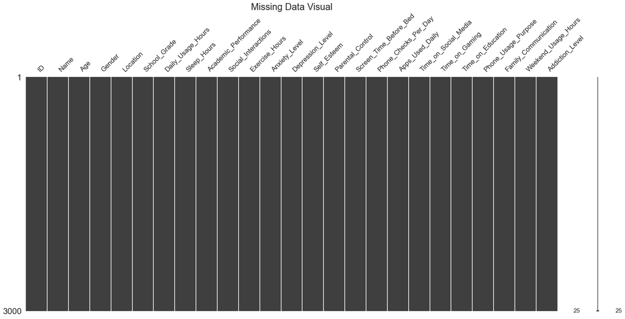

```python
"""
Having explored these 3 options, there are neither any omitted nor duplicated data points in this data set. There is no need to impute or remove any data.
We can finally visualize it, just in case. This code is borrowed and changed for my dataset from (1)
"""

import warnings
warnings.simplefilter('ignore', DeprecationWarning)
%matplotlib inline

# External package: conda install missingno
import missingno as mn

mn.matrix(df)
plt.title("Missing Data Visual",fontsize=22)
```

### Data Visualization (4.5 points total)

*Visualize basic feature distributions.*

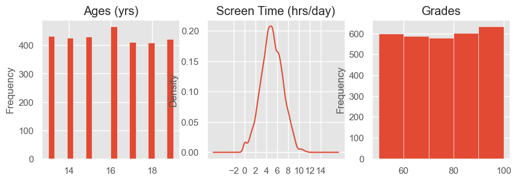

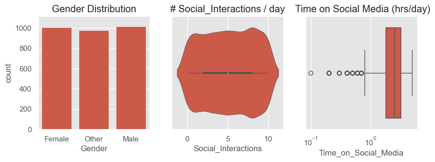

```python
# Plot a histogram and kernel density estimate to see how well the data is distributed
# All the code below is adapted from (1). I note where adjustments are made for each visual.

plt.style.use('ggplot')

## Ages

fig = plt.figure(figsize=(10,3))

plt.subplot(1,3,1)
df.Age.plot.hist(bins=20) # 20 is somewhat arbitrary
plt.title('Ages (yrs)')


## Daily_Usage_Hours

plt.subplot(1,3,2)
df.Daily_Usage_Hours.plot.kde(bw_method=0.15)
plt.xticks(np.arange(-2,15,2))
plt.title('Screen Time (hrs/day)')


## Academic_Performance

plt.subplot(1,3,3)
df.Academic_Performance.plot.hist(bins=5)
plt.title('Grades')

plt.show()


## Gender - github copilot adapted my code to improve scaling and readability in the graph

fig = plt.figure(figsize=(10,3))

plt.subplot(1,3,1)
sns.countplot(x="Gender", data=df)
plt.title('Gender Distribution')
plt.ylim(0, df["Gender"].value_counts().max() * 1.1)  # Zoom in a bit above the tallest bar


## Social_Interactions

plt.subplot(1,3,2)
sns.violinplot(x="Social_Interactions", data=df)
plt.title('# Social_Interactions / day')


## Time_on_Social_Media

plt.subplot(1,3,3)
sns.boxplot(x="Time_on_Social_Media", data=df, log_scale=True)
plt.title(' Time on Social Media (hrs/day)')

plt.show()
```

*Plot the dynamic range and exploratory distribution plots (like boxplots, histograms, kernel density estimation) to better understand the data. Describe anything meaningful or potentially useful you discover from these visualizations. These may also help to understand what data is missing or needs imputation. Note: You can also use data from other sources to bolster visualizations. Visualize at least five plots, at least one categorical.*

Explaining each plot:

- **Age**

  I chose a histogram over a KDE because age is discrete. The KDE made the visualization multimodal and even more confusing. This visual shows me that there's a roughly equal split between ages of people surveyed and that all the ages are indeed teenagers (13-19). 16 looks to be the most common age, but not significantly so.
- **Screen Time**

  I chose a KDE over a histogram because screen time is continuous. The KDE shows that there's a roughly normal distribution of time spent on the device, with most people spending around 5 hrs/day. I chose a bandwidth of 0.15 to provide a little bit of attention to the small minority bumps around 0 and 10. There is a little bit of the tail going into negative time but this is just an artifact of KDE with no meaning whatsoever.
- **Grades**

  I chose a histogram for this visualization because I want to group the grades into letter scores. The histogram allows me to see what the disributions look like once they're grouped. It shows me that there's a roughly equal distribution of grades with slightly more people having higher grades than lower.
- **Gender**

  The situation is pretty much the same with gender as with grades. There's pretty much an equal split between males, females, and other. Based off this information and the previous 3 visuals as well, the conducted survey was very well sampled and could yield very generalizable results.
- **Social Interactions**

  I chose a violin plot here because a boxplot wouldn't have allowed me to emphasize the little bump around 8 hours. While the median and percentiles show me that there's a normal split between how many offline interactions someone has daily, this bump shows me that more people have a decent amount of offline social interactions.
- **Time on Social Media**

  I chose a boxplot here because I suspected there'd be much variability in how much time is spent on social media. With a log scale I can see that you're an outlier if you spend less than 1 hour on social media per day. While the median and percentiles are roughly evenly far apart, the median tends slightly more toward spending more time on social media.

```
count     3000
unique       5
top          F
freq       649
Name: letter_grade, dtype: object
```

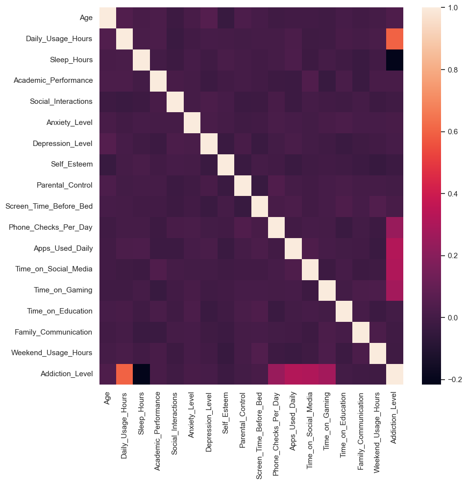

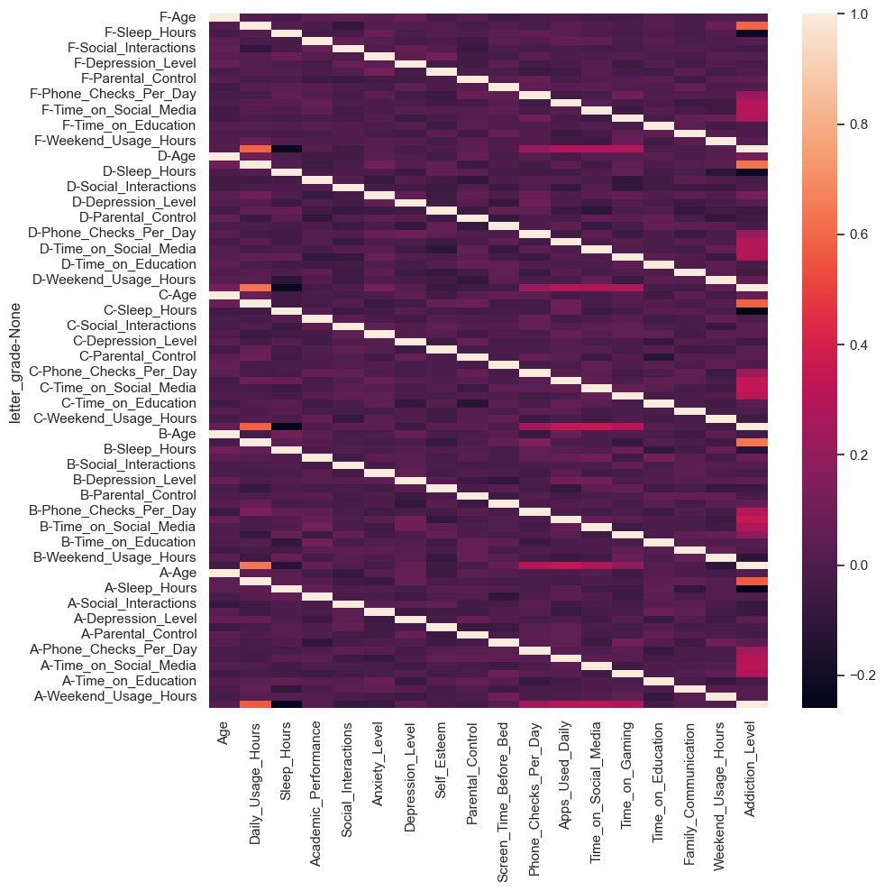

```python
"""
Finally, it's worthwhile to see how correlated everything is.
This code is adapted from (1) where I just changed the vars_to_use.
"""

cmap = sns.set_theme(style="darkgrid") # one of the many styles to plot using
vars_to_use = ['Age', 'Daily_Usage_Hours', 'Sleep_Hours', 'Academic_Performance', 'Social_Interactions',
               'Anxiety_Level', 'Depression_Level', 'Self_Esteem', 'Parental_Control', 'Screen_Time_Before_Bed',
               'Phone_Checks_Per_Day', 'Apps_Used_Daily', 'Time_on_Social_Media', 'Time_on_Gaming', 'Time_on_Education',
               'Family_Communication', 'Weekend_Usage_Hours', 'Addiction_Level']

f, ax = plt.subplots(figsize=(10,10))
sns.heatmap(df[vars_to_use].corr(), cmap=cmap, annot=False)

# The code below is adapted from (1). I changed the discretization to suit the grade buckets I want.
cut_values = [49,60,70,80,90,100]
cut_labels = ['F','D','C','B','A']

df['letter_grade'] = pd.cut(df['Academic_Performance'],
                            cut_values,
                            labels=cut_labels) # this creates a new variable

print(df.letter_grade.describe())

df_grouped = df.groupby(by=['letter_grade'])

f, ax = plt.subplots(figsize=(10,10))
sns.heatmap(df_grouped[vars_to_use].corr(), cmap=cmap, annot=False)
```

Interestingly, there's very little correlation between most of these features. The ones that are highly correlated lie on the addiction level row and make some sense. The one that caught my attention the most is the association between phone addiction and time spent on gaming.

The results don't seem to vary too much between letter grades (same orange/black patterns as well as peach/pink ones) but I can notice some minute differences (especially between B and the rest of the grades). This helped me find an interesting exploration question (Q2).

*[2.5 points] Ask three interesting questions that are relevant to your dataset and explore visuals that help answer these questions. Use whichever visualization method is appropriate for your data. Important: Interpret the implications for each visualization.*

**Q1: Is academic perfomance better predicted by time spent on social media or time spent on gaming?**

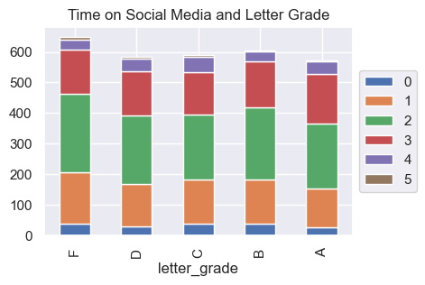

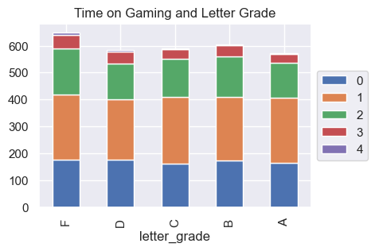

```python
# This code is adapted from (1) to work with my data

# Time on Social Media and Letter Grade
plt.figure(figsize=(15,3))
ax1 = plt.subplot(1,3,1)

pd.crosstab([df['letter_grade']], # categories to cross tabulate
            df.Time_on_Social_Media.astype(int)).plot(kind='bar', stacked=True, ax=ax1)
plt.legend(loc='center left', bbox_to_anchor=(1, 0.5))
plt.title('Time on Social Media and Letter Grade')
plt.show()

# Time on Gaming and Letter Grade
plt.figure(figsize=(15,3))
ax1 = plt.subplot(1,3,1)
pd.crosstab([df['letter_grade']], # categories to cross tabulate
            df.Time_on_Gaming.astype(int)).plot(kind='bar', stacked=True, ax=ax1)

plt.legend(loc='center left', bbox_to_anchor=(1, 0.5))
plt.title('Time on Gaming and Letter Grade')
plt.show()
```

It's important to be cautious about these comparisons because the gaming data had only 5 clusters while the social media data had 6 clusters. Nevertheless, this doesn't seem to be too big of an issue if I look at each time across letter grades.

All the letter grades show roughly equal usage for their particular group. In other words, approximately the same number of A through F students spent 0, 1, 2, or 3 hours on gaming (or social media, which would extend to the same number of students across grades in the 4 hour bucket). Interestingly, both the social media and gaming groups show that F students contained the most people who spent the most time for that group, followed by the D students. The A - C students only ever reach one below the maximum number of hours for that group (3 for gaming and 4 for social media). This shows a potential weak negative correlation between grade and time spent on either gaming or social media.

**Q2: Which letter grade is most addicted to their phone?**

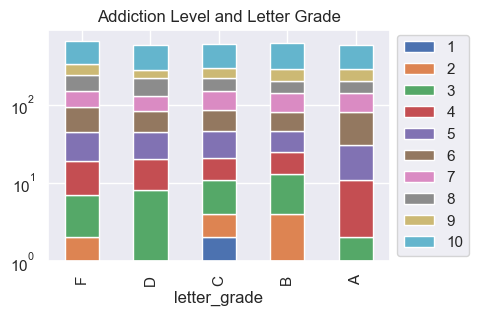

```python
# Time on Social Media and Letter Grade
plt.figure(figsize=(15,3))
ax1 = plt.subplot(1,3,1)

pd.crosstab([df['letter_grade']], # categories to cross tabulate
            df.Addiction_Level.astype(int)).plot(kind='bar', stacked=True, ax=ax1, logy=True)
plt.legend(loc='center left', bbox_to_anchor=(1, 0.5))
plt.title('Addiction Level and Letter Grade')
plt.show()
```

I use the logy scale because very high addiction (10) dominates the graph and squishes the rest of the categories. The logy scale also helps because there are more addiction categories for each grade relative to the times fromt he previous question.

**Q3: Does gender mediate phone addiction?**

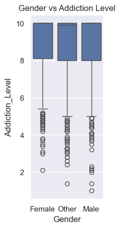

```python
plt.subplot(1,3,1)
sns.boxplot(x="Gender", y="Addiction_Level", data=df)
plt.title('Gender vs Addiction Level')

plt.show()
```

This boxplot shows that gender doesn't mediate or predict social media addiction. All three gender groups were equally very addicted to their phones (10). Interestingly, the 'other' gender group has a slightly smaller median addiction rating relative to males and females but the difference looks insignificant. All three groups had outliers if the addiction rating was 5 or less, though it's slighly higher for females. This indicates that females have less variability in their addiction levels and are slighly more likely to have a higher addiction to their phones relative to the 2 other gender groups. While the percentiles for males and other are most comparable, males seem to have the most variability in outliers. This cannot be due to a difference in population size since we have already seen all genders have about the same number of people.

### Exceptional Work (1 points total)

*Option B: Implement dimensionality reduction using uniform manifold approximation and projection (UMAP), then visualize and interpret the results.*

```python
"""
This code is adapted from the example section of the UMAP github:
https://github.com/lmcinnes/umap?tab=readme-ov-file
The main change I make is using my own dataset and only numeric columns for UMAP input.
"""
import umap

numeric_df = df.select_dtypes(include=["number"])

embedding = umap.UMAP(n_neighbors=5,
                      min_dist=0.3,
                      metric='correlation').fit_transform(numeric_df)

embedding2 = umap.UMAP(n_neighbors=10,
                      min_dist=0.3,
                      metric='correlation').fit_transform(numeric_df)
```

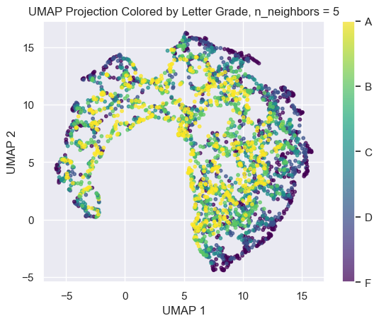

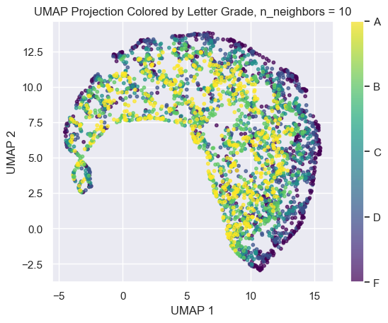

```python
# Visualize the UMAP embedding colored by letter grade
# This visualization was adapted from github copilot, which helped me make the scatterplot

plt.subplot(1,1,1)
scatter = plt.scatter(embedding[:,0], embedding[:,1], c=pd.Categorical(df['letter_grade']).codes, cmap='viridis', s=10, alpha=0.7)
plt.title('UMAP Projection Colored by Letter Grade, n_neighbors = 5')
plt.xlabel('UMAP 1')
plt.ylabel('UMAP 2')
cbar = plt.colorbar(scatter, ticks=range(len(df['letter_grade'].cat.categories)))
cbar.ax.set_yticklabels(df['letter_grade'].cat.categories)
plt.show()

plt.subplot(1,1,1)
scatter = plt.scatter(embedding2[:,0], embedding2[:,1], c=pd.Categorical(df['letter_grade']).codes, cmap='viridis', s=10, alpha=0.7)
plt.title('UMAP Projection Colored by Letter Grade, n_neighbors = 10')
plt.xlabel('UMAP 1')
plt.ylabel('UMAP 2')
cbar = plt.colorbar(scatter, ticks=range(len(df['letter_grade'].cat.categories)))
cbar.ax.set_yticklabels(df['letter_grade'].cat.categories)
plt.show()
```

We should expect to see high clustering of grade data points if they have similar features. However, there is pratcically no clustering among the grades, meaning knowing a grade doesn't predict other features from this dataset well. The axes are arbitrary so this visual provides information based off clustering.

*Give an explanation of UMAP dimensionality reduction methods.*

The only other technique I'm familiar with (and I only learned about this accidently) that does something similar to UMAP is Singular Value Decomposition. I will try to explain what UMAP is through comparing and contracting these two techniques.

*Similarities:*

UMAP is a technique for reducing the dimensionality of the dataset. This means that it can take our dataset with a large number of features and basically trim out the ones that contribute the least useful information over all. While more dimensions always provides more nuance and detail, the computational load isn't worth it when you can get a pretty decent representation for much less.

*Differences:*

Specifically, UMAP is used to quickly visualize high-dimensional data. Andy Coenen and Adam Pearce in their "Understanding UMAP" article explain how this works:

```
In the simplest sense, UMAP constructs a high dimensional graph representation of the data then optimizes a low-dimensional graph to be as structurally similar as possible.
```

The authors explain that the high dimensional graph representation is created by connecting nodes with overlapping radii. As the radius of a certain node increases, the likelihood of connecting with a farther node decreases (aka 'fuzziness'). Thus, the local neighbors are well connected while farther neighbors are less connected. This "ensures that local structure is preserved in balance with global structure" (Conen & Pearce).

From there UMAP optimally projects this high dimensional representation into a lower dimensional one, much like a dot product between two Nth dimensional vectors results in a optimal projection onto a lower dimension. The way UMAP does it though is much more complicated via a force-directed graph layout algorithm (Conen & Pearce).

The most important parameter for this algorithm is **n_neighbors**, which approximates tells us how many nearest neighbors will be connected while making the high-dimensional graph (Conen & Pearce). As the authors point out, if **n_neighbors** is low, no global sturcture can be captured. If it's too high, however, no local structure can be captured and thus features in the same region of latent space will cluster with far away features, making the cluster meaningless.

The other parameter, **min_dist**, "controls how tightly UMAP clumps points together" (Conen & Pearce). Thus, a higher **min_dist** means there's more range in the spread of data points while low **min_dist** results in high clumping on the points.

Sources Cited:

Coenen, Andy and Pearce, Adam. "Understanding UMAP". *Google PAIR*, https://pair-code.github.io/understanding-umap/.

Coenen, Andy and Pearce, Adam. "A deeper dive into UMAP theory". *Google PAIR*, https://pair-code.github.io/understanding-umap/supplement.html.